# Walmart_Retail_Forecasting

## Time Series Analysis and Forecasting Project

### Forecasting the Weekly Sales of a retail store and how it's impacted by the Holidays and Special events like Super Bowl

#### Problem Statement:

Retail industry is one of the fast paced industry where concepts like inventory optimization, network optimization, sales/demand forecasting play critical role. The product sales is heavily dependent on the customers' attention which is quite fickle and can be captured by the competitor at the drop of the hat. For example, if the product is not on the shelf, if the product cost is higher than the competitors' price or if the arrival of an online order is longer than the competitors'. For customer retention and increasing the profits, it is critical to forecast the demand as accurately as possible. It'll minimize the cost in the form of warehouse inventory and will also tackle the sudden demand surges during holidays and special events like the super bowl.

#### Project Aim:

The aim of the project is:

- To develop a statistical model which defines the relation between the weekly sales and predictors,
- Use this model to forecast the weekly demands as accurately as possible, and
- Observe the effect of the holidays/special events on the demand forecast.

#### Project Plan:

- Exploring and understanding the train dataset.
- Preprocessing the dataset by cleaning, manipulating the columns, wherever applicable.
- Using the cleaned dataset for the most efficient data modeling.
- Applying various regression algorithms on the data model to predict the weekly demand.
- Using the ARIMA/Exponential smoothing models before applying various regression algorithms for demand forecasting.
- Comparing the prediction/forecasting metric RMSE of all the algorithms and choosing the best algorithm.
- Predicting the weekly sales of the data in the test dataset.

#### About the dataset:

The dataset is split in 3 different .csv files. Each of the three .csv files are a piece of information regarding Walmart's weekly sales. The 3 files described are as follows:

- features.csv: This file contains additional data related to the store, department, and regional activity for the given dates. It contains the following fields:
  - Store Number.
  - Date of sale.
  - Temperature.
  - Fuel Price.
  - Markdown 1 to 5.
  - Consumer Price Index (CPI).
- Stores.csv: This file contains anonymized information about the 45 stores, indicating the type and size of the store:
  - Store.
  - Type.
  - Size.
- train.csv: This is the historical training data, which covers 2010–02–05 to 2012–11–01. Within this file you will find the following fields:
  - Store.
  - Dept.
  - date.
  - Weekly_Sales.
  - Is_Holiday.
- test.csv: This file is identical to train.csv, except the weekly sales is withheld .

### Part I - Exploratory Data Analysis (EDA)

#### Step 1 - Importing the libraries which might be useful for the project

```python
import numpy as np #To use np.arrays function on pandas series to feed them as arguments to regression models
import pandas as pd #To work with dataframes
import matplotlib.pyplot as plt #To plot various plots during exploration and viewing the results
import seaborn as sns #To plot various plots during exploration and viewing the results
import math as m #For using the sqrt() function
from datetime import datetime #To deal with dates of the week
from datetime import timedelta #To calculate the # of days

# import itertools
# import statsmodels.api as sm
# import statsmodels.tsa.api as smt
# import statsmodels.formula.api as smf

# from sklearn.model_selection import train_test_split
# from statsmodels.tsa.seasonal import seasonal_decompose as season
# from sklearn.metrics import mean_squared_error, mean_absolute_error
# from sklearn.metrics import accuracy_score, balanced_accuracy_score
# from sklearn.model_selection import cross_val_score

from sklearn.pipeline import make_pipeline, Pipeline
from sklearn.ensemble import RandomForestRegressor
# from sklearn import metrics

from sklearn.linear_model import LinearRegression #For applying linear regression algorithm
from sklearn import preprocessing

from statsmodels.tsa.holtwinters import ExponentialSmoothing #For applying exponential smoothing technique
from statsmodels.tsa.stattools import adfuller #, acf, pacf
from statsmodels.tsa.arima_model import ARIMA #For applying the ARIMA forecasting algorithm

from pmdarima.utils import decomposed_plot #To generate the decomposed plot of the sales into 3 components
from pmdarima.arima import decompose
from pmdarima import auto_arima

# To ignore python generated warnings
import warnings
warnings.filterwarnings("ignore")
```

#### Step 2 - Importing the datasets

```python
df_stores = pd.read_csv('stores.csv')
df_features = pd.read_csv('features.csv')
df_train = pd.read_csv('train.csv')
df_test = pd.read_csv('test.csv')
```

#### Step 3 - Data Exploration

```python
# A glimpse of the dataset df_stores
df_stores.head()
```

|  | Store | Type | Size |
| --- | --- | --- | --- |
| 0 | 1 | A | 151315 |
| 1 | 2 | A | 202307 |
| 2 | 3 | B | 37392 |
| 3 | 4 | A | 205863 |
| 4 | 5 | B | 34875 |

```python
# Exploring the number of rows and the datatype of all the columns
df_stores.info()
```

```
<class 'pandas.core.frame.DataFrame'>
RangeIndex: 45 entries, 0 to 44
Data columns (total 3 columns):
 #   Column  Non-Null Count  Dtype
---  ------  --------------  -----
 0   Store   45 non-null     int64
 1   Type    45 non-null     object
 2   Size    45 non-null     int64
dtypes: int64(2), object(1)
memory usage: 1.2+ KB
```

```python
# Checking the values and their frequency in the 'Type' column
df_stores['Type'].value_counts()
```

```
A    22
B    17
C     6
Name: Type, dtype: int64
```

There are three categories of store types: A, B and C. Are the 'Type' and 'Size' columns correlated?

```python
# Exploring the average size of the store in each category.
df_stores.groupby('Type')['Size'].mean()
```

```
Type
A    177247.727273
B    101190.705882
C     40541.666667
Name: Size, dtype: float64
```

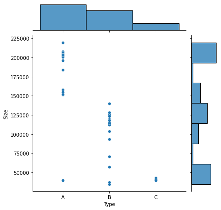

```python
#To find the distribution of the sizes among the 3 store Types
sns.jointplot(x = 'Type', y = 'Size', data = df_stores)
```

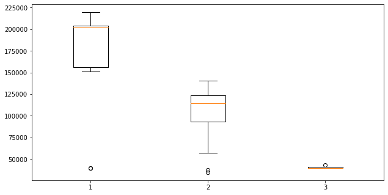

```python
#Plotting the box plot to explore further into the relation between the Type ans Size of the stores.
a = df_stores[df_stores['Type'] == 'A']['Size']
b = df_stores[df_stores['Type'] == 'B']['Size']
c = df_stores[df_stores['Type'] == 'C']['Size']
data = [a,b,c]

fig = plt.figure(figsize = (8, 4))

# Creating axes instance
ax = fig.add_axes([0, 0, 1, 1])

# Creating plot
bp = ax.boxplot(data)

# show plot
plt.show()
```

```python
df_stores[df_stores['Type'] == 'A']['Size'].describe()
```

```
count        22.000000
mean     177247.727273
std       49392.621098
min       39690.000000
25%      155840.750000
50%      202406.000000
75%      203819.000000
max      219622.000000
Name: Size, dtype: float64
```

#### Obeservations on the df_store dataframe:

- It appears from the scatter plot and the boxplot that there is significant difference between the sizes of the three types of stores. Type 'A' store being the largest and the Type 'C' stores being the smallest.
- Also, the variation in the size of the type 'A' is higher than the variation in the size of type 'C'.
- There are outliers in the type 'A' size as the 50% percentile or the median is different from the mean of the box plot.
- The outliers of the type 'A' are less than the mean. The 25%, 50%, 75% percentiles and the max are comparable but the min is different.

Either the outliers have been wrongly named as type 'A' or they might have been changed from previously 'C' type due to some business decision. We'll keep the table as it was.

```python
df_features.head() #glimpse of the df_features dataset
```

|  | Store | Date | Temperature | Fuel_Price | MarkDown1 | MarkDown2 | MarkDown3 | MarkDown4 | MarkDown5 | CPI | Unemployment | IsHoliday |
| --- | --- | --- | --- | --- | --- | --- | --- | --- | --- | --- | --- | --- |
| 0 | 1 | 2010-02-05 | 42.31 | 2.572 | NaN | NaN | NaN | NaN | NaN | 211.096358 | 8.106 | False |
| 1 | 1 | 2010-02-12 | 38.51 | 2.548 | NaN | NaN | NaN | NaN | NaN | 211.242170 | 8.106 | True |
| 2 | 1 | 2010-02-19 | 39.93 | 2.514 | NaN | NaN | NaN | NaN | NaN | 211.289143 | 8.106 | False |
| 3 | 1 | 2010-02-26 | 46.63 | 2.561 | NaN | NaN | NaN | NaN | NaN | 211.319643 | 8.106 | False |
| 4 | 1 | 2010-03-05 | 46.50 | 2.625 | NaN | NaN | NaN | NaN | NaN | 211.350143 | 8.106 | False |

```python
df_features.info()
```

```
<class 'pandas.core.frame.DataFrame'>
RangeIndex: 8190 entries, 0 to 8189
Data columns (total 12 columns):
 #   Column        Non-Null Count  Dtype
---  ------        --------------  -----
 0   Store         8190 non-null   int64
 1   Date          8190 non-null   object
 2   Temperature   8190 non-null   float64
 3   Fuel_Price    8190 non-null   float64
 4   MarkDown1     4032 non-null   float64
 5   MarkDown2     2921 non-null   float64
 6   MarkDown3     3613 non-null   float64
 7   MarkDown4     3464 non-null   float64
 8   MarkDown5     4050 non-null   float64
 9   CPI           7605 non-null   float64
 10  Unemployment  7605 non-null   float64
 11  IsHoliday     8190 non-null   bool
dtypes: bool(1), float64(9), int64(1), object(1)
memory usage: 712.0+ KB
```

```python
df_features.corr()
```

|  | Store | Temperature | Fuel_Price | MarkDown1 | MarkDown2 | MarkDown3 | MarkDown4 | MarkDown5 | CPI | Unemployment | IsHoliday |
| --- | --- | --- | --- | --- | --- | --- | --- | --- | --- | --- | --- |
| Store | 1.000000e+00 | -0.020566 | 0.066682 | -0.136967 | -0.044223 | -0.033279 | -0.005174 | -0.011970 | -0.209282 | 0.221153 | -4.186667e-16 |
| Temperature | -2.056605e-02 | 1.000000 | 0.101354 | -0.124979 | -0.321888 | -0.077552 | -0.064194 | -0.003241 | 0.164426 | 0.150890 | -1.619056e-01 |
| Fuel_Price | 6.668205e-02 | 0.101354 | 1.000000 | 0.066122 | -0.193461 | -0.057168 | -0.008546 | -0.021926 | -0.186696 | -0.033360 | -7.823797e-02 |
| MarkDown1 | -1.369671e-01 | -0.124979 | 0.066122 | 1.000000 | 0.021289 | -0.089841 | 0.810455 | 0.085967 | -0.044327 | 0.020501 | 1.526209e-01 |
| MarkDown2 | -4.422331e-02 | -0.321888 | -0.193461 | 0.021289 | 1.000000 | -0.053555 | -0.046595 | -0.008166 | -0.044896 | -0.001692 | 2.994476e-01 |
| MarkDown3 | -3.327926e-02 | -0.077552 | -0.057168 | -0.089841 | -0.053555 | 1.000000 | -0.062785 | -0.016026 | -0.020166 | -0.003464 | 4.452239e-01 |
| MarkDown4 | -5.173997e-03 | -0.064194 | -0.008546 | 0.810455 | -0.046595 | -0.062785 | 1.000000 | 0.042952 | -0.053868 | 0.021905 | 1.348406e-01 |
| MarkDown5 | -1.196994e-02 | -0.003241 | -0.021926 | 0.085967 | -0.008166 | -0.016026 | 0.042952 | 1.000000 | 0.001526 | 0.031847 | -2.462956e-02 |
| CPI | -2.092824e-01 | 0.164426 | -0.186696 | -0.044327 | -0.044896 | -0.020166 | -0.053868 | 0.001526 | 1.000000 | -0.303110 | 1.008430e-03 |
| Unemployment | 2.211525e-01 | 0.150890 | -0.033360 | 0.020501 | -0.001692 | -0.003464 | 0.021905 | 0.031847 | -0.303110 | 1.000000 | -2.644393e-03 |
| IsHoliday | -4.186667e-16 | -0.161906 | -0.078238 | 0.152621 | 0.299448 | 0.445224 | 0.134841 | -0.024630 | 0.001008 | -0.002644 | 1.000000e+00 |

#### Observation on the df_features dataframe:

```python
df_train.head()
```

|  | Store | Dept | Date | Weekly_Sales | IsHoliday |
| --- | --- | --- | --- | --- | --- |
| 0 | 1 | 1 | 2010-02-05 | 24924.50 | False |
| 1 | 1 | 1 | 2010-02-12 | 46039.49 | True |
| 2 | 1 | 1 | 2010-02-19 | 41595.55 | False |
| 3 | 1 | 1 | 2010-02-26 | 19403.54 | False |
| 4 | 1 | 1 | 2010-03-05 | 21827.90 | False |

```python
df_train.info()
```

```
<class 'pandas.core.frame.DataFrame'>
RangeIndex: 421570 entries, 0 to 421569
Data columns (total 5 columns):
 #   Column        Non-Null Count   Dtype
---  ------        --------------   -----
 0   Store         421570 non-null  int64
 1   Dept          421570 non-null  int64
 2   Date          421570 non-null  object
 3   Weekly_Sales  421570 non-null  float64
 4   IsHoliday     421570 non-null  bool
dtypes: bool(1), float64(1), int64(2), object(1)
memory usage: 13.3+ MB
```

```python
df_train.describe()
```

|  | Store | Dept | Weekly_Sales |
| --- | --- | --- | --- |
| count | 421570.000000 | 421570.000000 | 421570.000000 |
| mean | 22.200546 | 44.260317 | 15981.258123 |
| std | 12.785297 | 30.492054 | 22711.183519 |
| min | 1.000000 | 1.000000 | -4988.940000 |
| 25% | 11.000000 | 18.000000 | 2079.650000 |
| 50% | 22.000000 | 37.000000 | 7612.030000 |
| 75% | 33.000000 | 74.000000 | 20205.852500 |
| max | 45.000000 | 99.000000 | 693099.360000 |

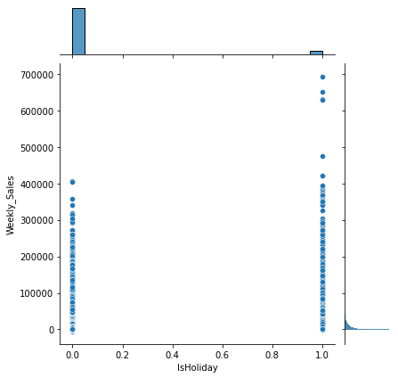

```python
sns.jointplot(x = 'IsHoliday', y = 'Weekly_Sales', data = df_train)
```

```python
df_train.groupby('IsHoliday')['Weekly_Sales'].mean()
```

```
IsHoliday
False    15901.445069
True     17035.823187
Name: Weekly_Sales, dtype: float64
```

```python
((17035.82 - 15901.45) / 15901.45)*100
```

```
7.1337519534382015
```

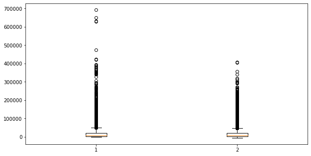

```python
holiday = df_train[df_train['IsHoliday'] == True]['Weekly_Sales']
no_holiday = df_train[df_train['IsHoliday'] == False]['Weekly_Sales']
data = [holiday, no_holiday]
fig = plt.figure(figsize = (8,4))
# Creating axes instance
ax = fig.add_axes([0, 0, 1, 1])

# Creating plot
bp = ax.boxplot(data)

# show plot
plt.show()
```

```python
df_train['Store'].nunique()
```

```
45
```

```python
print(sorted(df_train['Store'].value_counts().keys()))
```

```
[1, 2, 3, 4, 5, 6, 7, 8, 9, 10, 11, 12, 13, 14, 15, 16, 17, 18, 19, 20, 21, 22, 23, 24, 25, 26, 27, 28, 29, 30, 31, 32, 33, 34, 35, 36, 37, 38, 39, 40, 41, 42, 43, 44, 45]
```

```python
df_train['Dept'].nunique()
```

```
81
```

```python
print(sorted(df_train['Dept'].value_counts().keys()))
```

```
[1, 2, 3, 4, 5, 6, 7, 8, 9, 10, 11, 12, 13, 14, 16, 17, 18, 19, 20, 21, 22, 23, 24, 25, 26, 27, 28, 29, 30, 31, 32, 33, 34, 35, 36, 37, 38, 39, 40, 41, 42, 43, 44, 45, 46, 47, 48, 49, 50, 51, 52, 54, 55, 56, 58, 59, 60, 65, 67, 71, 72, 74, 77, 78, 79, 80, 81, 82, 83, 85, 87, 90, 91, 92, 93, 94, 95, …
```

```python
df_train['IsHoliday'].value_counts()
```

```
False    391909
True      29661
Name: IsHoliday, dtype: int64
```

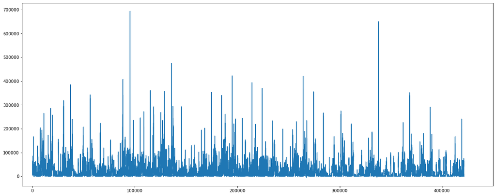

```python
fig = plt.figure(figsize = (20, 8))
plt.plot(df_train['Weekly_Sales'])
plt.xlim(-10000, 450000)
plt.show()
```

```python
df_train[df_train['Weekly_Sales'] <= 0]['Dept'].value_counts()
```

```
47    273
18    181
54    159
19     89
94     77
49     69
80     68
59     44
78     43
72     34
51     29
98     29
45     25
96     22
48     20
```

[output cut: 37 more lines]

#### Merging the 3 dataset for further exploration and discovery of correlations

```python
df = df_train.merge(df_features, on = ['Store', 'Date'], how = 'inner') \
             .merge(df_stores, on = 'Store', how = 'inner')
df.head()
```

|  | Store | Dept | Date | Weekly_Sales | IsHoliday_x | Temperature | Fuel_Price | MarkDown1 | MarkDown2 | MarkDown3 | MarkDown4 | MarkDown5 | CPI | Unemployment | IsHoliday_y | Type | Size |
| --- | --- | --- | --- | --- | --- | --- | --- | --- | --- | --- | --- | --- | --- | --- | --- | --- | --- |
| 0 | 1 | 1 | 2010-02-05 | 24924.50 | False | 42.31 | 2.572 | NaN | NaN | NaN | NaN | NaN | 211.096358 | 8.106 | False | A | 151315 |
| 1 | 1 | 2 | 2010-02-05 | 50605.27 | False | 42.31 | 2.572 | NaN | NaN | NaN | NaN | NaN | 211.096358 | 8.106 | False | A | 151315 |
| 2 | 1 | 3 | 2010-02-05 | 13740.12 | False | 42.31 | 2.572 | NaN | NaN | NaN | NaN | NaN | 211.096358 | 8.106 | False | A | 151315 |
| 3 | 1 | 4 | 2010-02-05 | 39954.04 | False | 42.31 | 2.572 | NaN | NaN | NaN | NaN | NaN | 211.096358 | 8.106 | False | A | 151315 |
| 4 | 1 | 5 | 2010-02-05 | 32229.38 | False | 42.31 | 2.572 | NaN | NaN | NaN | NaN | NaN | 211.096358 | 8.106 | False | A | 151315 |

```python
df.drop('IsHoliday_y', axis = 1, inplace = True)
```

```python
df.rename(columns = {'IsHoliday_x' : 'IsHoliday'}, inplace = True)
```

```python
df.head()
```

|  | Store | Dept | Date | Weekly_Sales | IsHoliday | Temperature | Fuel_Price | MarkDown1 | MarkDown2 | MarkDown3 | MarkDown4 | MarkDown5 | CPI | Unemployment | Type | Size |
| --- | --- | --- | --- | --- | --- | --- | --- | --- | --- | --- | --- | --- | --- | --- | --- | --- |
| 0 | 1 | 1 | 2010-02-05 | 24924.50 | False | 42.31 | 2.572 | NaN | NaN | NaN | NaN | NaN | 211.096358 | 8.106 | A | 151315 |
| 1 | 1 | 2 | 2010-02-05 | 50605.27 | False | 42.31 | 2.572 | NaN | NaN | NaN | NaN | NaN | 211.096358 | 8.106 | A | 151315 |
| 2 | 1 | 3 | 2010-02-05 | 13740.12 | False | 42.31 | 2.572 | NaN | NaN | NaN | NaN | NaN | 211.096358 | 8.106 | A | 151315 |
| 3 | 1 | 4 | 2010-02-05 | 39954.04 | False | 42.31 | 2.572 | NaN | NaN | NaN | NaN | NaN | 211.096358 | 8.106 | A | 151315 |
| 4 | 1 | 5 | 2010-02-05 | 32229.38 | False | 42.31 | 2.572 | NaN | NaN | NaN | NaN | NaN | 211.096358 | 8.106 | A | 151315 |

```python
df.shape
```

```
(421570, 16)
```

```python
df_train[df_train['Weekly_Sales'] <= 0].shape
```

```
(1358, 5)
```

```python
(1358/421570)*100
```

```
0.3221291837654482
```

The rows with impossible Weekly Sales values are just ~0.3% of the actual dataset. They can be eliminated.

```python
df_new = df[df['Weekly_Sales'] > 0]
```

```python
df_new.shape #Number of rows have reduced in the new dataset after removing negative or 0 sales value rows
```

```
(420212, 16)
```

```python
df_new['Date'].head()
```

```
0    2010-02-05
1    2010-02-05
2    2010-02-05
3    2010-02-05
4    2010-02-05
Name: Date, dtype: object
```

```python
df_new['Date'].tail()
```

```
421565    2012-10-26
421566    2012-10-26
421567    2012-10-26
421568    2012-10-26
421569    2012-10-26
Name: Date, dtype: object
```

```python
print(sorted(df_new[df_new['IsHoliday'] == True]['Date'].value_counts().keys()))
```

```
['2010-02-12', '2010-09-10', '2010-11-26', '2010-12-31', '2011-02-11', '2011-09-09', '2011-11-25', '2011-12-30', '2012-02-10', '2012-09-07']
```

```python
df_new.corr()
```

|  | Store | Dept | Weekly_Sales | IsHoliday | Temperature | Fuel_Price | MarkDown1 | MarkDown2 | MarkDown3 | MarkDown4 | MarkDown5 | CPI | Unemployment | Size |
| --- | --- | --- | --- | --- | --- | --- | --- | --- | --- | --- | --- | --- | --- | --- |
| Store | 1.000000 | 0.024258 | -0.085117 | -0.000522 | -0.050230 | 0.065321 | -0.119676 | -0.034993 | -0.031475 | -0.009991 | -0.026777 | -0.211261 | 0.208759 | -0.182763 |
| Dept | 0.024258 | 1.000000 | 0.148749 | 0.000663 | 0.004727 | 0.003544 | -0.002512 | 0.000018 | 0.001855 | 0.004176 | 0.000295 | -0.007178 | 0.007787 | -0.002491 |
| Weekly_Sales | -0.085117 | 0.148749 | 1.000000 | 0.012843 | -0.002339 | 0.000089 | 0.085325 | 0.024565 | 0.060304 | 0.045325 | 0.090561 | -0.021162 | -0.025806 | 0.244117 |
| IsHoliday | -0.000522 | 0.000663 | 0.012843 | 1.000000 | -0.155775 | -0.078155 | -0.035632 | 0.334327 | 0.428364 | -0.000459 | -0.053696 | -0.001933 | 0.010555 | 0.000797 |
| Temperature | -0.050230 | 0.004727 | -0.002339 | -0.155775 | 1.000000 | 0.143700 | -0.040498 | -0.323891 | -0.096843 | -0.063955 | -0.017616 | 0.182223 | 0.096768 | -0.058413 |
| Fuel_Price | 0.065321 | 0.003544 | 0.000089 | -0.078155 | 0.143700 | 1.000000 | 0.061302 | -0.220680 | -0.102146 | -0.045033 | -0.128017 | -0.164199 | -0.033915 | 0.003632 |
| MarkDown1 | -0.119676 | -0.002512 | 0.085325 | -0.035632 | -0.040498 | 0.061302 | 1.000000 | 0.024601 | -0.108189 | 0.819175 | 0.160412 | -0.055522 | 0.050103 | 0.345732 |
| MarkDown2 | -0.034993 | 0.000018 | 0.024565 | 0.334327 | -0.323891 | -0.220680 | 0.024601 | 1.000000 | -0.050146 | -0.007582 | -0.007410 | -0.039782 | 0.020839 | 0.108843 |
| MarkDown3 | -0.031475 | 0.001855 | 0.060304 | 0.428364 | -0.096843 | -0.102146 | -0.108189 | -0.050146 | 1.000000 | -0.071148 | -0.026475 | -0.023820 | 0.012866 | 0.048935 |
| MarkDown4 | -0.009991 | 0.004176 | 0.045325 | -0.000459 | -0.063955 | -0.045033 | 0.819175 | -0.007582 | -0.071148 | 1.000000 | 0.107895 | -0.049693 | 0.024919 | 0.168266 |
| MarkDown5 | -0.026777 | 0.000295 | 0.090561 | -0.053696 | -0.017616 | -0.128017 | 0.160412 | -0.007410 | -0.026475 | 0.107895 | 1.000000 | 0.060375 | -0.003834 | 0.304814 |
| CPI | -0.211261 | -0.007178 | -0.021162 | -0.001933 | 0.182223 | -0.164199 | -0.055522 | -0.039782 | -0.023820 | -0.049693 | 0.060375 | 1.000000 | -0.299887 | -0.003903 |
| Unemployment | 0.208759 | 0.007787 | -0.025806 | 0.010555 | 0.096768 | -0.033915 | 0.050103 | 0.020839 | 0.012866 | 0.024919 | -0.003834 | -0.299887 | 1.000000 | -0.068335 |
| Size | -0.182763 | -0.002491 | 0.244117 | 0.000797 | -0.058413 | 0.003632 | 0.345732 | 0.108843 | 0.048935 | 0.168266 | 0.304814 | -0.003903 | -0.068335 | 1.000000 |

#### Exploring the difference in the sales for each holiday/special day as compared to the regular days

```python
#Creating 4 columns each with holidays and filling the elements with Booleans.

# Super bowl dates in train set
df_new.loc[(df_new['Date'] == '2010-02-12')|(df_new['Date'] == '2011-02-11')|(df_new['Date'] == '2012-02-10'),'Super_Bowl'] = True
df_new.loc[(df_new['Date'] != '2010-02-12')&(df_new['Date'] != '2011-02-11')&(df_new['Date'] != '2012-02-10'),'Super_Bowl'] = False

# Labor day dates in train set
df_new.loc[(df_new['Date'] == '2010-09-10')|(df_new['Date'] == '2011-09-09')|(df_new['Date'] == '2012-09-07'),'Labor_Day'] = True
df_new.loc[(df_new['Date'] != '2010-09-10')&(df_new['Date'] != '2011-09-09')&(df_new['Date'] != '2012-09-07'),'Labor_Day'] = False

# Thanksgiving dates in train set
df_new.loc[(df_new['Date'] == '2010-11-26')|(df_new['Date'] == '2011-11-25'),'Thanksgiving'] = True
df_new.loc[(df_new['Date'] != '2010-11-26')&(df_new['Date'] != '2011-11-25'),'Thanksgiving'] = False

#Christmas dates in train set
df_new.loc[(df_new['Date'] == '2010-12-31')|(df_new['Date'] == '2011-12-30'),'Christmas'] = True
df_new.loc[(df_new['Date'] != '2010-12-31')&(df_new['Date'] != '2011-12-30'),'Christmas'] = False
```

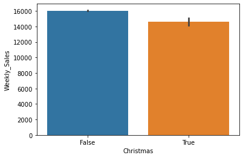

```python
sns.barplot(x = 'Christmas', y = 'Weekly_Sales', data = df_new)
```

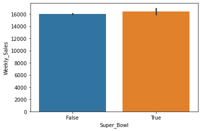

```python
sns.barplot(x = 'Super_Bowl', y = 'Weekly_Sales', data = df_new)
```

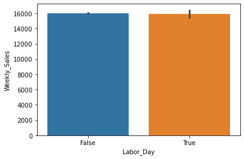

```python
sns.barplot(x = 'Labor_Day', y = 'Weekly_Sales', data = df_new)
```

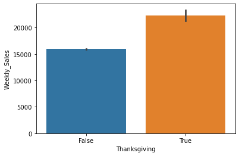

```python
sns.barplot(x = 'Thanksgiving', y = 'Weekly_Sales', data = df_new)
```

- Observations on the impact of each holiday/special day on the sales:
  - **Christmas**: The average sales were actually less that the regular days so this holiday doesn't have huge impact on the weekly sales.
  - **Super Bowl**: The average sales have increased but the increase doesn't appear to be highly significant.
  - **Labor Day**: The average sales are almost the same as the average sales of a regular day.
  - **Thanksgiving**: The average sales are significantly higher than the regular day average sales. The Black Friday sales could be the reason behind this significant difference.

#### Exploring the effect of store size on the weekly sales:

```python
df_new.groupby(['Super_Bowl', 'Type'])['Weekly_Sales'].mean()
```

```
Super_Bowl  Type
False       A       20138.055908
            B       12286.739293
            C        9536.110508
True        A       20612.757674
            B       12467.035506
            C       10179.271884
Name: Weekly_Sales, dtype: float64
```

```python
df_new.groupby(['Christmas', 'Type'])['Weekly_Sales'].mean()
```

```
Christmas  Type
False      A       20174.350209
           B       12301.986116
           C        9570.951973
True       A       18310.167535
           B       11488.988057
           C        8031.520607
Name: Weekly_Sales, dtype: float64
```

```python
df_new.groupby(['Labor_Day', 'Type'])['Weekly_Sales'].mean()
```

```
Labor_Day  Type
False      A       20151.210941
           B       12294.954138
           C        9542.098293
True       A       20004.267422
           B       12084.304642
           C        9893.459258
Name: Weekly_Sales, dtype: float64
```

```python
df_new.groupby(['Thanksgiving', 'Type'])['Weekly_Sales'].mean()
```

```
Thanksgiving  Type
False         A       20044.007801
              B       12197.717405
              C        9547.377807
True          A       27397.776346
              B       18733.973971
              C        9696.566616
Name: Weekly_Sales, dtype: float64
```

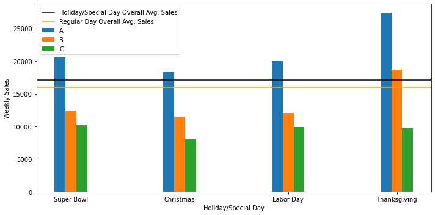

```python
columns = ['Super Bowl', 'Christmas', 'Labor Day', 'Thanksgiving']
a_mean = [20612.757674, 18310.167535, 20004.267422, 27397.776346]
b_mean = [12467.035506, 11488.988057, 12084.304642, 18733.973971]
c_mean = [10179.271884, 8031.520607, 9893.459258, 9696.566616]
x = np.arange(4)
w = 0.1

fig, ax = plt.subplots(figsize = (10,5))
ax1 = ax.bar(x - w, a_mean, w, label = 'A')
ax2 = ax.bar(x, b_mean, w, label = 'B')
ax3 = ax.bar(x + w, c_mean, w, label = 'C')

plt.axhline(y = 17094.3, color = 'black', label = 'Holiday/Special Day Overall Avg. Sales')
plt.axhline(y = 15951.82, color = 'orange', label = 'Regular Day Overall Avg. Sales')


ax.set_xticks(x)
ax.set_ylabel('Weekly Sales')
ax.set_xlabel('Holiday/Special Day')
ax.set_xticklabels(columns)
ax.legend()

fig.tight_layout()

plt.show()
```

#### Observations on the impact of the store size and the holidays combined on the weekly sales:

- For all the holidays/special days, the average sales of the A type stores is the highest and is above the average as expected.
- Only for the Thanksgiving the average sales of the B type store is above the average.
- None of the average sales of C type stores is higher than the average holiday/special day sales.

##### Thus, the top weekly sales occurs in the Type A stores during the Thanksgiving holiday.

This could be obvious because of the size of A which is approx 4 times that of the size of C and approx 1.7 times that of the size of B.

#### Exploring the weekly sales as an impact of different stores and departments:

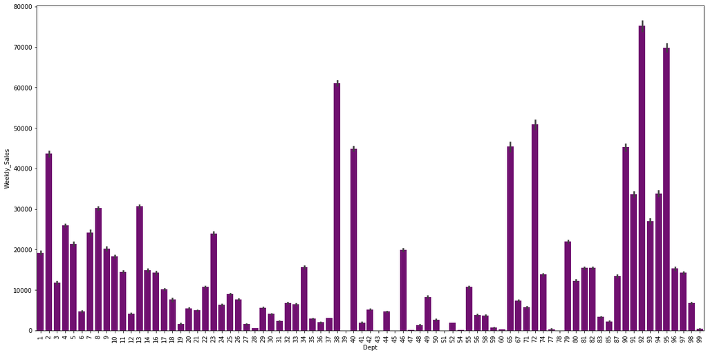

```python
plt.figure(figsize = (20,10))
sns.barplot(x = "Dept", y = 'Weekly_Sales', data = df_new, color = 'purple')
plt.xticks(rotation = 90)
plt.show()
```

The departments having the top 5 weekly sales are 92, 95, 38, 72, and 65 in the order of highest to lowest weekly sales.

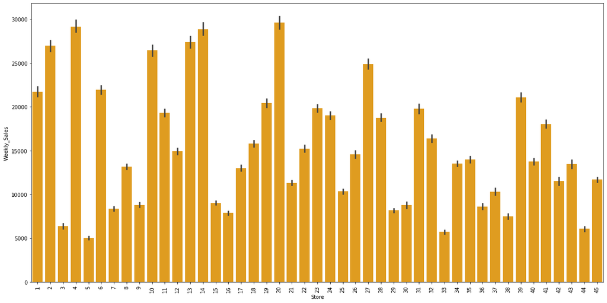

```python
plt.figure(figsize = (20,10))
sns.barplot(x = "Store", y = 'Weekly_Sales', data = df_new, color = 'orange')
plt.xticks(rotation = 90)
plt.show()
```

```python
#Imputing 0 for NaN values of MarkDown columns
df_new.info()
```

```
<class 'pandas.core.frame.DataFrame'>
Int64Index: 420212 entries, 0 to 421569
Data columns (total 20 columns):
 #   Column        Non-Null Count   Dtype
---  ------        --------------   -----
 0   Store         420212 non-null  int64
 1   Dept          420212 non-null  int64
 2   Date          420212 non-null  object
 3   Weekly_Sales  420212 non-null  float64
 4   IsHoliday     420212 non-null  bool
 5   Temperature   420212 non-null  float64
 6   Fuel_Price    420212 non-null  float64
 7   MarkDown1     150181 non-null  float64
 8   MarkDown2     110904 non-null  float64
 9   MarkDown3     136651 non-null  float64
 10  MarkDown4     134518 non-null  float64
 11  MarkDown5     150929 non-null  float64
 12  CPI           420212 non-null  float64
 13  Unemployment  420212 non-null  float64
 14  Type          420212 non-null  object
 15  Size          420212 non-null  int64
 16  Super_Bowl    420212 non-null  object
 17  Labor_Day     420212 non-null  object
 18  Thanksgiving  420212 non-null  object
 19  Christmas     420212 non-null  object
dtypes: bool(1), float64(10), int64(3), object(6)
memory usage: 80.6+ MB
```

Only the MarkDown columns have NaN values in them so we can directly use the .fillna() method on the entire dataframe

```python
df_new.fillna(0, inplace = True)
```

```python
df_new.info()
```

```
<class 'pandas.core.frame.DataFrame'>
Int64Index: 420212 entries, 0 to 421569
Data columns (total 20 columns):
 #   Column        Non-Null Count   Dtype
---  ------        --------------   -----
 0   Store         420212 non-null  int64
 1   Dept          420212 non-null  int64
 2   Date          420212 non-null  object
 3   Weekly_Sales  420212 non-null  float64
 4   IsHoliday     420212 non-null  bool
 5   Temperature   420212 non-null  float64
 6   Fuel_Price    420212 non-null  float64
 7   MarkDown1     420212 non-null  float64
 8   MarkDown2     420212 non-null  float64
 9   MarkDown3     420212 non-null  float64
 10  MarkDown4     420212 non-null  float64
 11  MarkDown5     420212 non-null  float64
 12  CPI           420212 non-null  float64
 13  Unemployment  420212 non-null  float64
 14  Type          420212 non-null  object
 15  Size          420212 non-null  int64
 16  Super_Bowl    420212 non-null  bool
 17  Labor_Day     420212 non-null  bool
 18  Thanksgiving  420212 non-null  bool
 19  Christmas     420212 non-null  bool
dtypes: bool(5), float64(10), int64(3), object(2)
memory usage: 69.4+ MB
```

#### Comparing the Year on Year Monthly sales pattern.

```python
#Extracting the datetime information from the date column
df_new['Date'] = pd.to_datetime(df_new['Date'])
df_new['Year'] = df_new['Date'].dt.year
df_new['Month'] = df_new['Date'].dt.month
df_new['Week'] = df_new['Date'].dt.week
```

```python
df_new.groupby(['Year','Month'])['Weekly_Sales'].mean()
```

```
Year  Month
2010  2        16123.339183
      3        15480.222209
      4        15786.479121
      5        16063.976174
      6        16551.606753
      7        16009.268745
      8        16205.333619
      9        15172.175282
      10       14839.055563
      11       17363.277836
      12       19642.617795
2011  1        14054.378885
      2        15906.833033
      3        15245.219561
```

[output cut: 20 more lines]

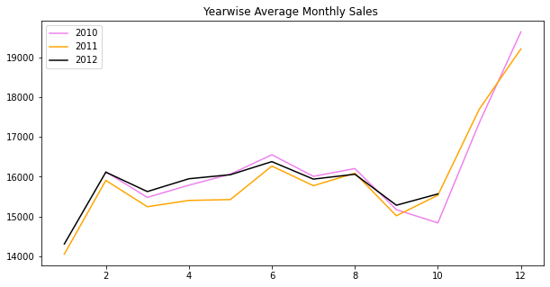

```python
plt.figure(figsize = (10,5))
plt.plot(df_new.groupby(['Year','Month'])['Weekly_Sales'].mean()[2010], label = '2010', color = 'violet')
plt.plot(df_new.groupby(['Year','Month'])['Weekly_Sales'].mean()[2011], label = '2011', color = 'orange')
plt.plot(df_new.groupby(['Year','Month'])['Weekly_Sales'].mean()[2012], label = '2012', color = 'black')
plt.title('Yearwise Average Monthly Sales ')
plt.legend()
plt.show()
```

#### Comparing the year on Year Weekly Sales pattern

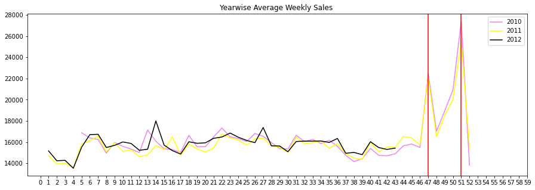

```python
plt.figure(figsize = (15,5))
plt.plot(df_new.groupby(['Year','Week'])['Weekly_Sales'].mean()[2010], label = '2010', color = 'violet')
plt.plot(df_new.groupby(['Year','Week'])['Weekly_Sales'].mean()[2011], label = '2011', color = 'yellow')
plt.plot(df_new.groupby(['Year','Week'])['Weekly_Sales'].mean()[2012], label = '2012', color = 'black')
plt.title('Yearwise Average Weekly Sales ')
plt.legend()
plt.xticks(np.array(range(0, 60)))
plt.axvline(x = 47, color = 'red')
plt.axvline(x = 51, color = 'red')
plt.show()
```

#### Observations on the Year on Year weekly Sales:

- The observations are same as that of the year on year monthly sales.
- The peaks at the end are of week 47 and week 51 which are the weeks of Thanksgiving (Black Friday Sales) and Christmas.

#### Exploring the impact of the Fuel Price, Temperature, CPI, and Unemployement on the Weekly Sales

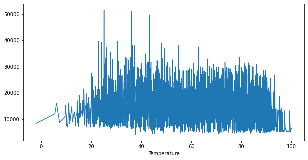

```python
plt.figure(figsize = (10, 5))
df_new.groupby(['Temperature'])['Weekly_Sales'].mean().plot()
```

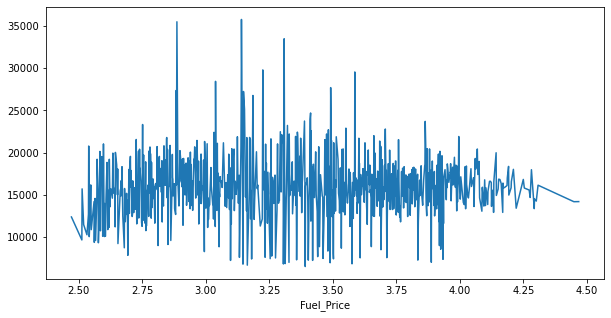

```python
plt.figure(figsize = (10, 5))
df_new.groupby(['Fuel_Price'])['Weekly_Sales'].mean().plot()
```

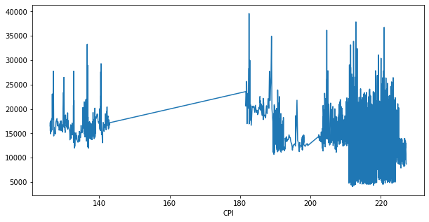

```python
plt.figure(figsize = (10, 5))
df_new.groupby(['CPI'])['Weekly_Sales'].mean().plot()
```

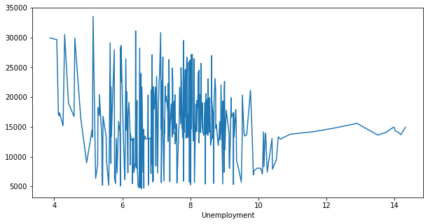

```python
plt.figure(figsize = (10, 5))
df_new.groupby(['Unemployment'])['Weekly_Sales'].mean().plot()
```

#### Observations on the impact of Fuel Price, Temperature, CPI and Unemployment on the Weekly Sales:

- These columns don't seem to have a siginificant effect on the Weekly Sales. The plots like noise.

I'll drop these columns as they don't have any effect on the Weekly Sales.

### Part 2 - Applying the Regression Models

#### First we'll apply the Linear Regression algorithm to get a benchmark on the metric

```python
df_new.head()
```

|  | Store | Dept | Date | Weekly_Sales | IsHoliday | Temperature | Fuel_Price | MarkDown1 | MarkDown2 | MarkDown3 | ... | Unemployment | Type | Size | Super_Bowl | Labor_Day | Thanksgiving | Christmas | Year | Month | Week |
| --- | --- | --- | --- | --- | --- | --- | --- | --- | --- | --- | --- | --- | --- | --- | --- | --- | --- | --- | --- | --- | --- |
| 0 | 1 | 1 | 2010-02-05 | 24924.50 | False | 42.31 | 2.572 | 0.0 | 0.0 | 0.0 | ... | 8.106 | A | 151315 | False | False | False | False | 2010 | 2 | 5 |
| 1 | 1 | 2 | 2010-02-05 | 50605.27 | False | 42.31 | 2.572 | 0.0 | 0.0 | 0.0 | ... | 8.106 | A | 151315 | False | False | False | False | 2010 | 2 | 5 |
| 2 | 1 | 3 | 2010-02-05 | 13740.12 | False | 42.31 | 2.572 | 0.0 | 0.0 | 0.0 | ... | 8.106 | A | 151315 | False | False | False | False | 2010 | 2 | 5 |
| 3 | 1 | 4 | 2010-02-05 | 39954.04 | False | 42.31 | 2.572 | 0.0 | 0.0 | 0.0 | ... | 8.106 | A | 151315 | False | False | False | False | 2010 | 2 | 5 |
| 4 | 1 | 5 | 2010-02-05 | 32229.38 | False | 42.31 | 2.572 | 0.0 | 0.0 | 0.0 | ... | 8.106 | A | 151315 | False | False | False | False | 2010 | 2 | 5 |

5 rows × 23 columns

We need to change the boolean values to numeric values of 0 and 1. This is applicable to the columns IsHoliday, Super_Bowl, Labor_Day, Thanksgiving, and Christmas

```python
df_new['Type'] = df_new['Type'].replace({'A' : 1, 'B' : 2, 'C' : 3})
df_new['Super_Bowl'] = df_new['Super_Bowl'].astype(int)
df_new['Thanksgiving'] = df_new['Thanksgiving'].astype(int)
df_new['Labor_Day'] = df_new['Labor_Day'].astype(int)
df_new['Christmas'] = df_new['Christmas'].astype(int)
df_new['IsHoliday'] = df_new['IsHoliday'].astype(int)
```

```python
df_new.head()
```

|  | Store | Dept | Date | Weekly_Sales | IsHoliday | Temperature | Fuel_Price | MarkDown1 | MarkDown2 | MarkDown3 | ... | Unemployment | Type | Size | Super_Bowl | Labor_Day | Thanksgiving | Christmas | Year | Month | Week |
| --- | --- | --- | --- | --- | --- | --- | --- | --- | --- | --- | --- | --- | --- | --- | --- | --- | --- | --- | --- | --- | --- |
| 0 | 1 | 1 | 2010-02-05 | 24924.50 | 0 | 42.31 | 2.572 | 0.0 | 0.0 | 0.0 | ... | 8.106 | 1 | 151315 | 0 | 0 | 0 | 0 | 2010 | 2 | 5 |
| 1 | 1 | 2 | 2010-02-05 | 50605.27 | 0 | 42.31 | 2.572 | 0.0 | 0.0 | 0.0 | ... | 8.106 | 1 | 151315 | 0 | 0 | 0 | 0 | 2010 | 2 | 5 |
| 2 | 1 | 3 | 2010-02-05 | 13740.12 | 0 | 42.31 | 2.572 | 0.0 | 0.0 | 0.0 | ... | 8.106 | 1 | 151315 | 0 | 0 | 0 | 0 | 2010 | 2 | 5 |
| 3 | 1 | 4 | 2010-02-05 | 39954.04 | 0 | 42.31 | 2.572 | 0.0 | 0.0 | 0.0 | ... | 8.106 | 1 | 151315 | 0 | 0 | 0 | 0 | 2010 | 2 | 5 |
| 4 | 1 | 5 | 2010-02-05 | 32229.38 | 0 | 42.31 | 2.572 | 0.0 | 0.0 | 0.0 | ... | 8.106 | 1 | 151315 | 0 | 0 | 0 | 0 | 2010 | 2 | 5 |

5 rows × 23 columns

```python
df_new['Super_Bowl'].value_counts()
```

```
0    411339
1      8873
Name: Super_Bowl, dtype: int64
```

```python
df_new.drop(['Fuel_Price', 'CPI', 'Temperature', 'Unemployment'], axis = 1, inplace = True)
```

```python
df_new.head()
```

|  | Store | Dept | Date | Weekly_Sales | IsHoliday | MarkDown1 | MarkDown2 | MarkDown3 | MarkDown4 | MarkDown5 | Type | Size | Super_Bowl | Labor_Day | Thanksgiving | Christmas | Year | Month | Week |
| --- | --- | --- | --- | --- | --- | --- | --- | --- | --- | --- | --- | --- | --- | --- | --- | --- | --- | --- | --- |
| 0 | 1 | 1 | 2010-02-05 | 24924.50 | 0 | 0.0 | 0.0 | 0.0 | 0.0 | 0.0 | 1 | 151315 | 0 | 0 | 0 | 0 | 2010 | 2 | 5 |
| 1 | 1 | 2 | 2010-02-05 | 50605.27 | 0 | 0.0 | 0.0 | 0.0 | 0.0 | 0.0 | 1 | 151315 | 0 | 0 | 0 | 0 | 2010 | 2 | 5 |
| 2 | 1 | 3 | 2010-02-05 | 13740.12 | 0 | 0.0 | 0.0 | 0.0 | 0.0 | 0.0 | 1 | 151315 | 0 | 0 | 0 | 0 | 2010 | 2 | 5 |
| 3 | 1 | 4 | 2010-02-05 | 39954.04 | 0 | 0.0 | 0.0 | 0.0 | 0.0 | 0.0 | 1 | 151315 | 0 | 0 | 0 | 0 | 2010 | 2 | 5 |
| 4 | 1 | 5 | 2010-02-05 | 32229.38 | 0 | 0.0 | 0.0 | 0.0 | 0.0 | 0.0 | 1 | 151315 | 0 | 0 | 0 | 0 | 2010 | 2 | 5 |

```python
df_new.drop('MarkDown4', axis = 1, inplace = True)
```

```python
df_new.drop('MarkDown5', axis = 1, inplace = True)
```

```python
df_new.drop('Date', axis = 1, inplace = True)
```

```python
df_new.head()
```

|  | Store | Dept | Weekly_Sales | IsHoliday | MarkDown1 | MarkDown2 | MarkDown3 | Type | Size | Super_Bowl | Labor_Day | Thanksgiving | Christmas | Year | Month | Week |
| --- | --- | --- | --- | --- | --- | --- | --- | --- | --- | --- | --- | --- | --- | --- | --- | --- |
| 0 | 1 | 1 | 24924.50 | 0 | 0.0 | 0.0 | 0.0 | 1 | 151315 | 0 | 0 | 0 | 0 | 2010 | 2 | 5 |
| 1 | 1 | 2 | 50605.27 | 0 | 0.0 | 0.0 | 0.0 | 1 | 151315 | 0 | 0 | 0 | 0 | 2010 | 2 | 5 |
| 2 | 1 | 3 | 13740.12 | 0 | 0.0 | 0.0 | 0.0 | 1 | 151315 | 0 | 0 | 0 | 0 | 2010 | 2 | 5 |
| 3 | 1 | 4 | 39954.04 | 0 | 0.0 | 0.0 | 0.0 | 1 | 151315 | 0 | 0 | 0 | 0 | 2010 | 2 | 5 |
| 4 | 1 | 5 | 32229.38 | 0 | 0.0 | 0.0 | 0.0 | 1 | 151315 | 0 | 0 | 0 | 0 | 2010 | 2 | 5 |

```python
#Creating the train and test set from this dataset itself
train_df = df_new[:int(len(df_new)*0.7)]
test_df = df_new[int(len(df_new)*0.7):]
```

```python
predictors = list(df_new.columns)
predictors.remove('Weekly_Sales')
```

```python
print(predictors)
```

```
['Store', 'Dept', 'IsHoliday', 'MarkDown1', 'MarkDown2', 'MarkDown3', 'Type', 'Size', 'Super_Bowl', 'Labor_Day', 'Thanksgiving', 'Christmas', 'Year', 'Month', 'Week']
```

```python
response = 'Weekly_Sales'
```

```python
#Preparing the variables for the regression algorithms
x_train = train_df[predictors]
x_test = test_df[predictors]
y_train = train_df[response]
y_test = test_df[response]
```

```python
#Creating an object of LinearRegression()
from sklearn.metrics import mean_squared_error
lr = LinearRegression()
lr.fit(x_train, y_train)
print(lr.intercept_, '\n', lr.coef_, '\n', lr.score(x_train, y_train), '\n')
y_pred = lr.predict(x_test)
mse = mean_squared_error(y_test, y_pred)
print(mse)
```

```
860674.0599166806
 [-1.70200617e+02  8.69614883e+01  2.98996255e+02  5.71546626e-02
  4.55740020e-02  5.06906763e-02  2.59840274e+03  1.28717433e-01
  1.08614614e+03 -1.03069054e+03  4.11307068e+03 -3.86953003e+03
 -4.32273250e+02  7.21937502e+02 -1.14227942e+02]
 0.0814149740186384

354023813.43958867
```

The additive linear model for the weekly sales forecasting performed poorly: **R-Squared value ~ 8%** and **MSE = 354023813.44**. We need to look at advanced regression algorithms which would give us a lower MSE value.

#### Alternative function for Linear Regression with detailed summary

```python
import statsmodels.api as sm

#add constant to predictor variables
x_train_ols = sm.add_constant(x_train)

#fit linear regression model
model = sm.OLS(y_train, x_train_ols).fit()

#view model summary
print(model.summary())
```

```
                            OLS Regression Results
==============================================================================
Dep. Variable:           Weekly_Sales   R-squared:                       0.081
Model:                            OLS   Adj. R-squared:                  0.081
Method:                 Least Squares   F-statistic:                     1862.
Date:                Sun, 19 Mar 2023   Prob (F-statistic):               0.00
Time:                        11:44:22   Log-Likelihood:            -3.3714e+06
No. Observations:              294148   AIC:                         6.743e+06
Df Residuals:                  294133   BIC:                         6.743e+06
Df Model:                          14
Covariance Type:            nonrobust
================================================================================
                   coef    std err          t      P>|t|      [0.025      0.975]
--------------------------------------------------------------------------------
const         8.607e+05   1.33e+05      6.485      0.000    6.01e+05    1.12e+06
Store         -170.2006      5.372    -31.682      0.000    -180.730    -159.671
Dept            86.9615      1.417     61.383      0.000      84.185      89.738
IsHoliday      298.9963    159.630      1.873      0.061     -13.875     611.867
MarkDown1        0.0572      0.008      7.101      0.000       0.041       0.073
MarkDown2        0.0456      0.009      5.037      0.000       0.028       0.063
MarkDown3        0.0507      0.009      5.511      0.000       0.033       0.069
Type          2598.4027    171.332     15.166      0.000    2262.596    2934.209
Size             0.1287      0.002     78.119      0.000       0.125       0.132
Super_Bowl    1086.1461    286.528      3.791      0.000     524.559    1647.733
Labor_Day    -1030.6905    279.929     -3.682      0.000   -1579.343    -482.038
Thanksgiving  4113.0707    400.422     10.272      0.000    3328.254    4897.887
Christmas    -3869.5300    373.670    -10.355      0.000   -4601.913   -3137.147
Year          -432.2732     65.979     -6.552      0.000    -561.590    -302.956
Month          721.9375    155.292      4.649      0.000     417.569    1026.306
Week          -114.2279     35.720     -3.198      0.001    -184.238     -44.218
==============================================================================
Omnibus:                   201283.088   Durbin-Watson:                   1.331
Prob(Omnibus):                  0.000   Jarque-Bera (JB):          4810726.536
Skew:                           2.981   Prob(JB):                         0.00
Kurtosis:                      21.893   Cond. No.                     2.92e+20
==============================================================================

Notes:
[1] Standard Errors assume that the covariance matrix of the errors is correctly specified.
[2] The smallest eigenvalue is 8.32e-26. This might indicate that there are
strong multicollinearity problems or that the design matrix is singular.
```

#### Note:

Since the R2 value is too low, Linear Regression wouldn't perform well even if the columns are scaled. Also, from the above summary, all except 'IsHoliday' column are significant. We can now directly move on to Tree-based regression algorithms. The tree-based algorithms wouldn't be sensitive to the scales of the columns in the dataset.

```python
# from itertools import combinations
# from sklearn.model_selection import cross_val_score

# def best_subset(estimator, X, y, max_size=8, cv=5):
#     '''Calculates the best model of up to max_size features of X.
#        estimator must have a fit and score functions.
#         X must be a DataFrame.'''

#     n_features = X.shape[1]
#     subsets = (combinations(range(n_features), k + 1)
#                for k in range(min(n_features, max_size)))

#     best_size_subset = []
#     for subsets_k in subsets:  # for each list of subsets of the same size
#         best_score = -np.inf
#         best_subset = None
#         for subset in subsets_k: # for each subset
#             estimator.fit(X.iloc[:, list(subset)], y)
#             # get the subset with the best score among subsets of the same size
#             score = estimator.score(X.iloc[:, list(subset)], y)
#             if score > best_score:
#                 best_score, best_subset = score, subset
#         # to compare subsets of different sizes we must use CV
#         # first store the best subset of each size
#         best_size_subset.append(best_subset)

#     # compare best subsets of each size
#     best_score = -np.inf
#     best_subset = None
#     list_scores = []
#     for subset in best_size_subset:
#         score = cross_val_score(estimator, X.iloc[:, list(subset)], y, cv=cv).mean()
#         list_scores.append(score)
#         if score > best_score:
#             best_score, best_subset = score, subset

#     return best_subset, best_score, best_size_subset, list_scores
```

```python
# lr = LinearRegression()
# best_subset(lr, x_train, y_train, max_size = 4, cv = 5)
```

#### Applying the Tree Based Random Forest Algorithm to the dataset

```python
df_new.info()
```

```
<class 'pandas.core.frame.DataFrame'>
Int64Index: 420212 entries, 0 to 421569
Data columns (total 16 columns):
 #   Column        Non-Null Count   Dtype
---  ------        --------------   -----
 0   Store         420212 non-null  int64
 1   Dept          420212 non-null  int64
 2   Weekly_Sales  420212 non-null  float64
 3   IsHoliday     420212 non-null  int32
 4   MarkDown1     420212 non-null  float64
 5   MarkDown2     420212 non-null  float64
 6   MarkDown3     420212 non-null  float64
 7   Type          420212 non-null  int64
 8   Size          420212 non-null  int64
 9   Super_Bowl    420212 non-null  int32
 10  Labor_Day     420212 non-null  int32
 11  Thanksgiving  420212 non-null  int32
 12  Christmas     420212 non-null  int32
 13  Year          420212 non-null  int64
 14  Month         420212 non-null  int64
 15  Week          420212 non-null  int64
dtypes: float64(4), int32(5), int64(7)
memory usage: 62.6 MB
```

The first step of the application of the Random Forect Algorithm would be tune the hyperparameters.

```python
#Importing a function called pprint(), short for pretty print. This displays everything in a 'pretty' form :)
from pprint import pprint

#Importing the class from the sklearn.ensemble module
from sklearn.ensemble import RandomForestRegressor

#Inital random_state set as 42 (Similar to setting seed)
rf = RandomForestRegressor(random_state = 42)

# Look at parameters used by our current forest
print('Parameters currently in use:\n')
pprint(rf.get_params())
```

```
Parameters currently in use:

{'bootstrap': True,
 'ccp_alpha': 0.0,
 'criterion': 'mse',
 'max_depth': None,
 'max_features': 'auto',
 'max_leaf_nodes': None,
 'max_samples': None,
 'min_impurity_decrease': 0.0,
 'min_impurity_split': None,
 'min_samples_leaf': 1,
 'min_samples_split': 2,
 'min_weight_fraction_leaf': 0.0,
 'n_estimators': 100,
 'n_jobs': None,
 'oob_score': False,
 'random_state': 42,
 'verbose': 0,
 'warm_start': False}
```

There are **18** hyperparameters and optimizing all of them for the best result would take a lot of computational power which I don't have on my laptop, so I'll use only the following **6** hyperparameters for the tuning purpose:

1) n_estimators - The number of trees in the random forest. 2) max_features - Maximum number of predictors considered for splitting a node. 3) max_depth - Maximum number of levels in each of the n_estimators decision tree. 4) min_sample_split - Minimum number of data rows placed in a node before it's split. 5) min_samples_leaf - Minimum number of data rows allowed in a leaf node. 6) bootstrap - Method for sampling data points (with or without replacement).

We'll create a grid of the 6 hyperparameters listed above for the RandomizedSearchCV to search for the optimized combination of the hyperparameters. Since the run time was large I did only 3 iterations and used cross validation = 2.

```python
from sklearn.model_selection import RandomizedSearchCV

# Number of trees in random forest
n_estimators = [int(x) for x in np.linspace(start = 200, stop = 2000, num = 10)]

# Number of features to consider at every split
max_features = ['auto', 'sqrt']

# Maximum number of levels in tree
max_depth = [int(x) for x in np.linspace(10, 110, num = 11)]
max_depth.append(None)

# Minimum number of samples required to split a node
min_samples_split = [2, 5, 10]

# Minimum number of samples required at each leaf node
min_samples_leaf = [1, 2, 4]

# Method of selecting samples for training each tree
bootstrap = [True, False]

# Create the random grid
random_grid = {'n_estimators': n_estimators,
               'max_features': max_features,
               'max_depth': max_depth,
               'min_samples_split': min_samples_split,
               'min_samples_leaf': min_samples_leaf,
               'bootstrap': bootstrap}
pprint(random_grid)

# Use the random grid to search for best hyperparameters
# First create the base model to tune
rf = RandomForestRegressor()

# Random search of parameters, using 3 fold cross validation,
# search across 100 different combinations, and use all available cores
rf_random = RandomizedSearchCV(estimator = rf,
                               param_distributions = random_grid,
                               n_iter = 3,
                               cv = 2,
                               verbose=2,
                               random_state=42,
                               n_jobs = -1)

# Fit the random search model
rf_random.fit(x_train, y_train)
```

```
{'bootstrap': [True, False],
 'max_depth': [10, 20, 30, 40, 50, 60, 70, 80, 90, 100, 110, None],
 'max_features': ['auto', 'sqrt'],
 'min_samples_leaf': [1, 2, 4],
 'min_samples_split': [2, 5, 10],
 'n_estimators': [200, 400, 600, 800, 1000, 1200, 1400, 1600, 1800, 2000]}
Fitting 2 folds for each of 3 candidates, totalling 6 fits
```

```
RandomizedSearchCV(cv=2, estimator=RandomForestRegressor(), n_iter=3, n_jobs=-1,
                   param_distributions={'bootstrap': [True, False],
                                        'max_depth': [10, 20, 30, 40, 50, 60,
                                                      70, 80, 90, 100, 110,
                                                      None],
                                        'max_features': ['auto', 'sqrt'],
                                        'min_samples_leaf': [1, 2, 4],
                                        'min_samples_split': [2, 5, 10],
                                        'n_estimators': [200, 400, 600, 800,
                                                         1000, 1200, 1400, 1600,
                                                         1800, 2000]},
                   random_state=42, verbose=2)
```

```python
#Finding the best parameters for the algorithm
rf_random.best_params_
```

```
{'n_estimators': 200,
 'min_samples_split': 10,
 'min_samples_leaf': 2,
 'max_features': 'sqrt',
 'max_depth': 50,
 'bootstrap': True}
```

From the limited grid search due to computational power limitations for my laptop, the following are the values of the hyperparameters: 1) n_estimators: 200 2) min_samples_split: 10 3) min_samples_leaf: 2 4) max_features: 'sqrt' 5) max_depth: 50 6) bootstrap: True

```python
#Importing the RobustScaler
from sklearn.preprocessing import RobustScaler
rf = RandomForestRegressor(n_estimators=200,
                           random_state=42,
                           n_jobs=-1,
                           max_depth=50,
                           max_features = 'sqrt',
                           min_samples_split = 10,
                           min_samples_leaf = 2,
                           bootstrap = True)

#To make the dataset robust against any outliers
scaler = RobustScaler()

#making a pipe to use scaler and regressor together
pipe = make_pipeline(scaler,rf)

pipe.fit(x_train, y_train)

# predictions on train set
y_pred = pipe.predict(x_train)

# predictions on test set
y_pred_test = pipe.predict(x_test)

#Calculating the MSE
mse = mean_squared_error(y_test, y_pred_test)
print(mse)
```

```
105968862.3703026
```

From the above result, we can see that the use of the Random Forest algorithm along with the Robust Scaler in the pipeline has reduced the **MSE** from **354023813.44** to **105968862.37**

```python
(354023813.44 - 105968862.37)/354023813.44
```

```
0.7006730667626131
```

The percentage reduction of **~70%** in the MSE has been rather drastic. Good News!

Though the Tree Based models don't give you the exact sensitivity of the weekly sales (response variable) to the predictors but we can look at the importance order of the predictors, the most important being the first and the least important being last in the plot.

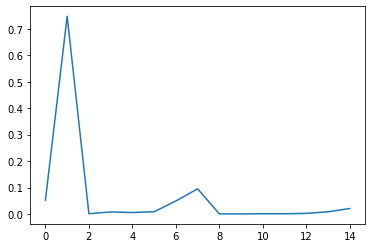

```python
plt.plot(rf.feature_importances_)
```

```python
x_train.info()
```

```
<class 'pandas.core.frame.DataFrame'>
Int64Index: 294148 entries, 0 to 295031
Data columns (total 15 columns):
 #   Column        Non-Null Count   Dtype
---  ------        --------------   -----
 0   Store         294148 non-null  int64
 1   Dept          294148 non-null  int64
 2   IsHoliday     294148 non-null  int32
 3   MarkDown1     294148 non-null  float64
 4   MarkDown2     294148 non-null  float64
 5   MarkDown3     294148 non-null  float64
 6   Type          294148 non-null  int64
 7   Size          294148 non-null  int64
 8   Super_Bowl    294148 non-null  int32
 9   Labor_Day     294148 non-null  int32
 10  Thanksgiving  294148 non-null  int32
 11  Christmas     294148 non-null  int32
 12  Year          294148 non-null  int64
 13  Month         294148 non-null  int64
 14  Week          294148 non-null  int64
dtypes: float64(3), int32(5), int64(7)
memory usage: 30.3 MB
```

```
Predictor ranking:
1. feature 1 (0.747633)
2. feature 7 (0.095077)
3. feature 0 (0.052245)
4. feature 6 (0.049116)
5. feature 14 (0.020604)
6. feature 5 (0.008518)
7. feature 13 (0.008187)
8. feature 3 (0.007651)
9. feature 4 (0.005573)
10. feature 12 (0.002284)
11. feature 2 (0.000950)
12. feature 10 (0.000922)
13. feature 11 (0.000737)
14. feature 8 (0.000270)
15. feature 9 (0.000236)
```

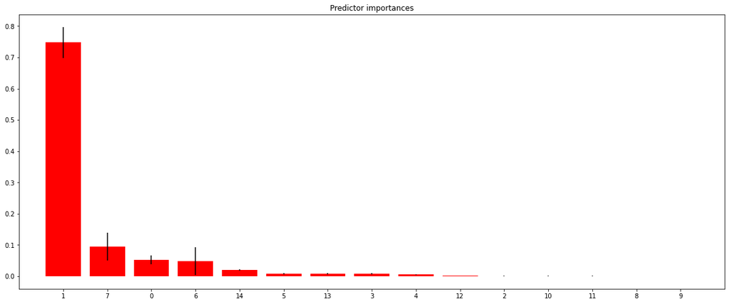

```python
importances = rf.feature_importances_
std = np.std([tree.feature_importances_ for tree in rf.estimators_],
             axis=0)
indices = np.argsort(importances)[::-1]

# Printing the feature ranking
print("Predictor ranking:")
for f in range(train_df.shape[1] - 1):
    print("%d. feature %d (%f)" % (f + 1, indices[f], importances[indices[f]]))

# Plotting the feature importances of the forest
plt.figure(figsize = (20,8))
plt.title("Predictor importances")
plt.bar(range(train_df.shape[1]-1), importances[indices],
       color="r", yerr=std[indices], align="center")
plt.xticks(range(train_df.shape[1]-1), indices)
plt.xlim([-1, train_df.shape[1]-1])
plt.show()
```

```python
low_imp_col = ['Labor_Day', 'Thanksgiving', 'Size', 'Super_Bowl']
```

```python
x_train_2 = x_train.drop(low_imp_col, axis = 1)
```

```python
x_test_2 = x_test.drop(low_imp_col, axis = 1)
```

```python
from sklearn.model_selection import RandomizedSearchCV

# Number of trees in random forest
n_estimators = [int(x) for x in np.linspace(start = 200, stop = 2000, num = 10)]

# Number of features to consider at every split
max_features = ['auto', 'sqrt']

# Maximum number of levels in tree
max_depth = [int(x) for x in np.linspace(10, 110, num = 11)]
max_depth.append(None)

# Minimum number of samples required to split a node
min_samples_split = [2, 5, 10]

# Minimum number of samples required at each leaf node
min_samples_leaf = [1, 2, 4]

# Method of selecting samples for training each tree
bootstrap = [True, False]

# Create the random grid
random_grid = {'n_estimators': n_estimators,
               'max_features': max_features,
               'max_depth': max_depth,
               'min_samples_split': min_samples_split,
               'min_samples_leaf': min_samples_leaf,
               'bootstrap': bootstrap}
pprint(random_grid)

# Use the random grid to search for best hyperparameters
# First create the base model to tune
rf = RandomForestRegressor()

# Random search of parameters, using 3 fold cross validation,
# search across 100 different combinations, and use all available cores
rf_random = RandomizedSearchCV(estimator = rf,
                               param_distributions = random_grid,
                               n_iter = 3,
                               cv = 2,
                               verbose=2,
                               random_state=42,
                               n_jobs = -1)

# Fit the random search model
rf_random.fit(x_train_2, y_train)
```

```
{'bootstrap': [True, False],
 'max_depth': [10, 20, 30, 40, 50, 60, 70, 80, 90, 100, 110, None],
 'max_features': ['auto', 'sqrt'],
 'min_samples_leaf': [1, 2, 4],
 'min_samples_split': [2, 5, 10],
 'n_estimators': [200, 400, 600, 800, 1000, 1200, 1400, 1600, 1800, 2000]}
Fitting 2 folds for each of 3 candidates, totalling 6 fits
```

```
RandomizedSearchCV(cv=2, estimator=RandomForestRegressor(), n_iter=3, n_jobs=-1,
                   param_distributions={'bootstrap': [True, False],
                                        'max_depth': [10, 20, 30, 40, 50, 60,
                                                      70, 80, 90, 100, 110,
                                                      None],
                                        'max_features': ['auto', 'sqrt'],
                                        'min_samples_leaf': [1, 2, 4],
                                        'min_samples_split': [2, 5, 10],
                                        'n_estimators': [200, 400, 600, 800,
                                                         1000, 1200, 1400, 1600,
                                                         1800, 2000]},
                   random_state=42, verbose=2)
```

```python
#Finding the best parameters for the algorithm
rf_random.best_params_
```

```
{'n_estimators': 600,
 'min_samples_split': 10,
 'min_samples_leaf': 4,
 'max_features': 'sqrt',
 'max_depth': 90,
 'bootstrap': False}
```

```python
#Importing the RobustScaler
from sklearn.preprocessing import RobustScaler
rf = RandomForestRegressor(n_estimators=600,
                           random_state=42,
                           n_jobs=-1,
                           max_depth=90,
                           max_features = 'sqrt',
                           min_samples_split = 10,
                           min_samples_leaf = 4,
                           bootstrap = False)

#To make the dataset robust against any outliers
scaler = RobustScaler()

#making a pipe to use scaler and regressor together
pipe = make_pipeline(scaler,rf)

pipe.fit(x_train_2, y_train)

# predictions on train set
y_pred = pipe.predict(x_train_2)

# predictions on test set
y_pred_test = pipe.predict(x_test_2)

#Calculating the MSE
mse = mean_squared_error(y_test, y_pred_test)
print(mse)
```

```
126355622.05901836
```

```python
126355622.06 - 105968862.37
```

```
20386759.689999998
```

```python
20386759.69/105968862.37
```

```
0.1923844347674297
```

```python
importances = rf.feature_importances_
std = np.std([tree.feature_importances_ for tree in rf.estimators_],
             axis=0)
indices = np.argsort(importances)[::-1]

# Printing the feature ranking
print("Predictor ranking:")
for f in range(x_train_2.shape[1] - 1):
    print("%d. feature %d (%f)" % (f + 1, indices[f], importances[indices[f]]))
```

```
Predictor ranking:
1. feature 1 (0.748063)
2. feature 0 (0.104316)
3. feature 6 (0.103866)
4. feature 10 (0.015242)
5. feature 5 (0.008120)
6. feature 3 (0.006485)
7. feature 9 (0.005991)
8. feature 4 (0.004484)
9. feature 8 (0.001386)
10. feature 2 (0.001221)
```

### Part 3: Applying the Time Series Models on the dataset

```python
df_new['Date'] = df[df['Weekly_Sales'] > 0]['Date']
```

```python
df_new.info()
```

```
<class 'pandas.core.frame.DataFrame'>
Int64Index: 420212 entries, 0 to 421569
Data columns (total 17 columns):
 #   Column        Non-Null Count   Dtype
---  ------        --------------   -----
 0   Store         420212 non-null  int64
 1   Dept          420212 non-null  int64
 2   Weekly_Sales  420212 non-null  float64
 3   IsHoliday     420212 non-null  int32
 4   MarkDown1     420212 non-null  float64
 5   MarkDown2     420212 non-null  float64
 6   MarkDown3     420212 non-null  float64
 7   Type          420212 non-null  int64
 8   Size          420212 non-null  int64
 9   Super_Bowl    420212 non-null  int32
 10  Labor_Day     420212 non-null  int32
 11  Thanksgiving  420212 non-null  int32
 12  Christmas     420212 non-null  int32
 13  Year          420212 non-null  int64
 14  Month         420212 non-null  int64
 15  Week          420212 non-null  int64
 16  Date          420212 non-null  object
dtypes: float64(4), int32(5), int64(7), object(1)
memory usage: 65.8+ MB
```

```python
#Changing the indices of the dataset to the dates from the Date column
df_new['Date'] = pd.to_datetime(df_new['Date'])
df_new.set_index('Date', inplace=True)
```

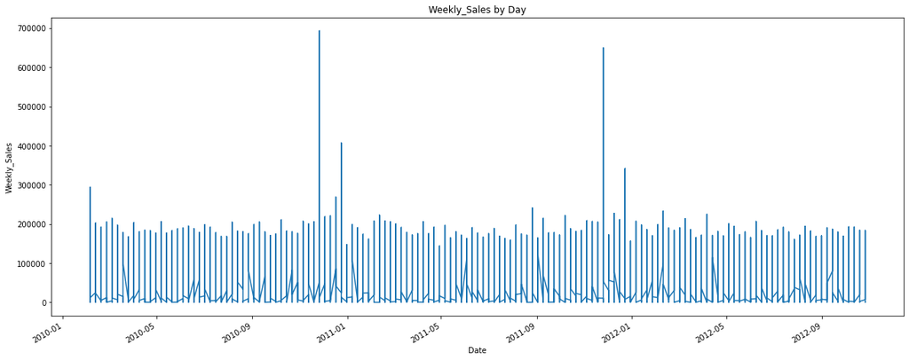

```python
plt.figure(figsize=(20,8))
df_new['Weekly_Sales'].plot()
plt.ylabel('Weekly_Sales')
plt.title('Weekly_Sales by Day')
plt.show()
```

Since the data has too many datapoints, I'll roll up weekly mean of the daily data(upsampling) using the resample() method.

```python
df_weekly = df_new.resample('W').mean()
```

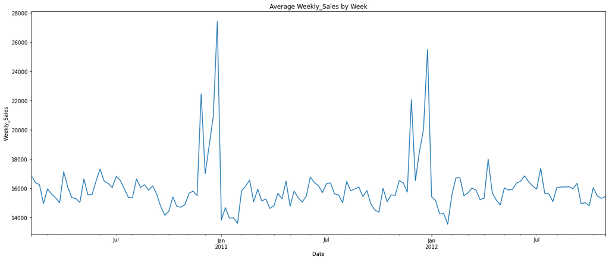

```python
plt.figure(figsize=(20,8))
df_weekly['Weekly_Sales'].plot()
plt.ylabel('Weekly_Sales')
plt.title('Average Weekly_Sales by Week')
plt.show()
```

Rolling up to see the monthly plot

```python
df_monthly = df_new.resample('MS').mean()
```

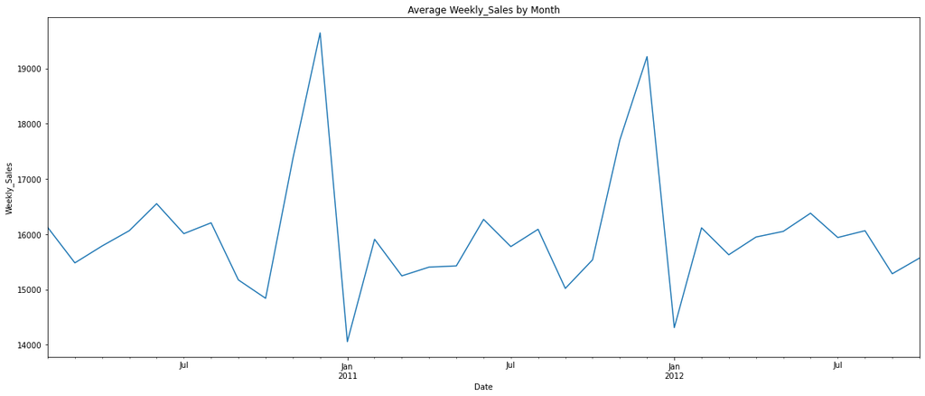

```python
plt.figure(figsize=(20,8))
df_monthly['Weekly_Sales'].plot()
plt.ylabel('Weekly_Sales')
plt.title('Average Weekly_Sales by Month')
plt.show()
```

Both the plots clearly show some seasonality:

But, I feel that the weekly sales is better than the monthly sales dataset as monthly sales looses the granularity as seen in the plot. For example, the twin peak in the month of Nov and Dec vanishes in the average monthly sales plot but weekly sales plot still has it.

I will use the average weekly sales dataset for further analysis and application of algorithms.

I'm already aware that there is seasonality in the data so I'll **not** apply the **Moving Average** or the **Simple Exponential Smoothing** techniques for this dataset.

I'll use the ADFuller test on then dataset to find whether the time series is stationary.

```python
result = adfuller(df_weekly['Weekly_Sales'])
```

```python
print(f' ADFuller statistics: {result[0]}\n',
      f'p-value: {result[1]}\n',
      f'critical values: {result[4]}')
```

```
 ADFuller statistics: -5.92710722373756
 p-value: 2.4290492082043886e-07
 critical values: {'1%': -3.47864788917503, '5%': -2.882721765644168, '10%': -2.578065326612056}
```

The ADFuller test shows that:

- The ADFuller statistics is negative.
- It's less than all the critical values.
- The p-value is practically 0

Though, the result of the test shows that the data is stationary, i'm still going to compare the results of applying algorithm to the dataset and the dataset with differencing/shifting/log transformation.

#### First, applying the algorithm to the dataset without correction techniques

```python
df_weekly.shape
```

```
(143, 16)
```

```python
len(df_weekly)
```

```
143
```

```python
int(143*0.7)
```

```
100
```

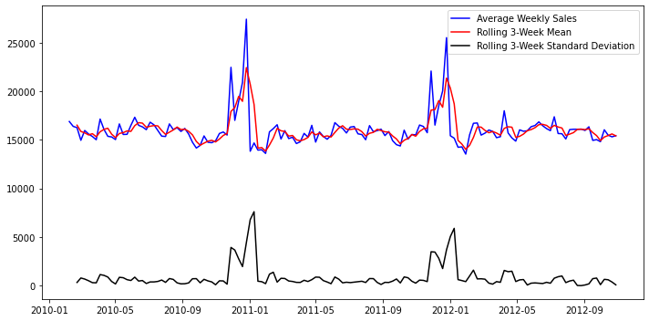

```python
# finding 2-weeks rolling mean and std
roll_mean = df_weekly['Weekly_Sales'].rolling(window = 3, center=False).mean()
roll_std = df_weekly['Weekly_Sales'].rolling(window = 3, center=False).std()

fig, ax = plt.subplots(figsize=(10, 5))
ax.plot(df_weekly['Weekly_Sales'], color='blue',label='Average Weekly Sales')
ax.plot(roll_mean, color='red', label='Rolling 3-Week Mean')
ax.plot(roll_std, color='black', label='Rolling 3-Week Standard Deviation')
ax.legend()

fig.tight_layout()
```

There appears to be difference in the time series average weekly sales and the 3-week standard deviation. Looks like the time series is not stationary after all. But still I'd like to compare the two results.

```python
#Splitting the data into train and test dataset
train_data_ts = df_weekly[:int(0.7*(len(df_weekly)))]
test_data_ts = df_weekly[int(0.7*(len(df_weekly))):]
```

```python
model_auto_arima = auto_arima(train_data_ts['Weekly_Sales'],
                              trace = True,
                              start_p = 0,
                              start_q = 0,
                              start_P = 0,
                              start_Q = 0,
                              max_p = 20,
                              max_q = 20,
                              max_P = 20,
                              max_Q = 20,
                              seasonal = True,
                              maxiter = 200,
                              information_criterion = 'aic',
                              stepwise = False,
                              suppress_warnings = True,
                              D = 1,
                              max_D = 10,
                              error_action = 'ignore',
                              approximation = False)
model_auto_arima.fit(train_data_ts['Weekly_Sales'])
```

```
 ARIMA(0,0,0)(0,0,0)[1] intercept   : AIC=1813.025, Time=0.02 sec
 ARIMA(0,0,1)(0,0,0)[1] intercept   : AIC=1807.863, Time=0.03 sec
 ARIMA(0,0,2)(0,0,0)[1] intercept   : AIC=1806.051, Time=0.06 sec
 ARIMA(0,0,3)(0,0,0)[1] intercept   : AIC=1805.480, Time=0.23 sec
 ARIMA(0,0,4)(0,0,0)[1] intercept   : AIC=1782.969, Time=0.20 sec
 ARIMA(0,0,5)(0,0,0)[1] intercept   : AIC=inf, Time=0.65 sec
 ARIMA(1,0,0)(0,0,0)[1] intercept   : AIC=1804.632, Time=0.02 sec
 ARIMA(1,0,1)(0,0,0)[1] intercept   : AIC=1805.301, Time=0.04 sec
 ARIMA(1,0,2)(0,0,0)[1] intercept   : AIC=1807.815, Time=0.06 sec
 ARIMA(1,0,3)(0,0,0)[1] intercept   : AIC=1808.903, Time=0.07 sec
 ARIMA(1,0,4)(0,0,0)[1] intercept   : AIC=1785.800, Time=0.14 sec
 ARIMA(2,0,0)(0,0,0)[1] intercept   : AIC=1803.865, Time=0.07 sec
 ARIMA(2,0,1)(0,0,0)[1] intercept   : AIC=1805.884, Time=0.06 sec
 ARIMA(2,0,2)(0,0,0)[1] intercept   : AIC=1804.457, Time=0.24 sec
 ARIMA(2,0,3)(0,0,0)[1] intercept   : AIC=1801.899, Time=0.23 sec
 ARIMA(3,0,0)(0,0,0)[1] intercept   : AIC=1805.864, Time=0.06 sec
 ARIMA(3,0,1)(0,0,0)[1] intercept   : AIC=1807.867, Time=0.08 sec
 ARIMA(3,0,2)(0,0,0)[1] intercept   : AIC=1805.831, Time=0.23 sec
 ARIMA(4,0,0)(0,0,0)[1] intercept   : AIC=1803.146, Time=0.07 sec
 ARIMA(4,0,1)(0,0,0)[1] intercept   : AIC=1799.692, Time=0.19 sec
 ARIMA(5,0,0)(0,0,0)[1] intercept   : AIC=1787.917, Time=0.32 sec

Best model:  ARIMA(0,0,4)(0,0,0)[1] intercept
Total fit time: 3.082 seconds
```

```
ARIMA(maxiter=200, order=(0, 0, 4), scoring_args={},
      seasonal_order=(0, 0, 0, 1), suppress_warnings=True)
```

```
              Prediction
Date
2012-01-08  17799.274925
2012-01-15  18384.593612
2012-01-22  18215.567690
2012-01-29  14875.126710
2012-02-05  16178.455618
```

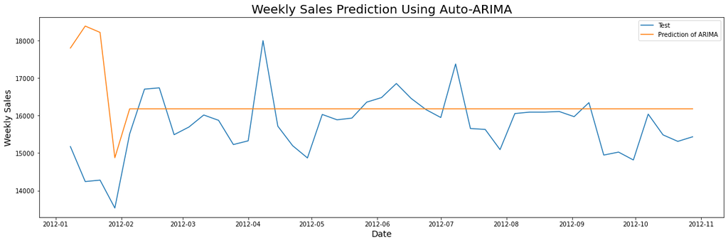

```python
y_pred = model_auto_arima.predict(n_periods=len(test_data_ts))
y_pred = pd.DataFrame(y_pred, index = test_data_ts.index, columns = ['Prediction'])
print(y_pred.head())

#Plotting the prediction and the test dataset values
plt.figure(figsize = (20,6))
plt.title('Weekly Sales Prediction Using Auto-ARIMA', fontsize = 20)
# plt.plot(train_data_ts['Weekly_Sales'], label = 'Train')
plt.plot(test_data_ts['Weekly_Sales'], label = 'Test')
plt.plot(y_pred, label = 'Prediction of ARIMA')
plt.legend(loc = 'best')
plt.xlabel('Date', fontsize = 14)
plt.ylabel('Weekly Sales', fontsize = 14)
plt.show()
```

```python
#Calculating the MSE
mse = mean_squared_error(test_data_ts['Weekly_Sales'], y_pred['Prediction'])
print(mse)
```

```
1435712.6094154245
```

#### Applying the differencing technique then applying the ARIMA on the time series

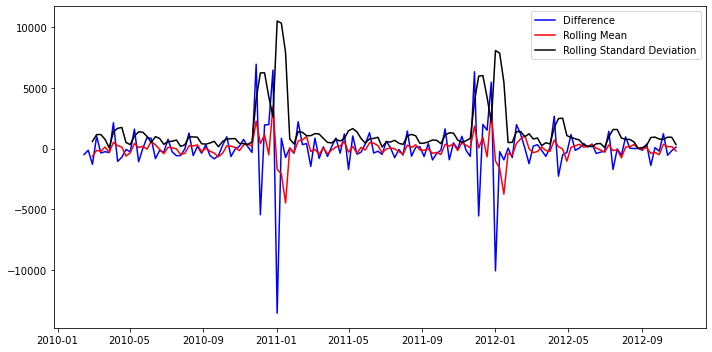

```python
df_week_diff = df_weekly['Weekly_Sales'].diff().dropna() #creating difference values

# taking mean and std of differenced data
diff_roll_mean = df_week_diff.rolling(window = 3, center=False).mean()
diff_roll_std = df_week_diff.rolling(window = 3, center=False).std()


fig, ax = plt.subplots(figsize=(10, 5))
ax.plot(df_week_diff, color='blue',label='Difference')
ax.plot(diff_roll_mean, color='red', label='Rolling Mean')
ax.plot(diff_roll_std, color='black', label='Rolling Standard Deviation')
ax.legend()

fig.tight_layout()
```

```python
train_data_diff = df_week_diff [:int(0.7*(len(df_week_diff )))]
test_data_diff = df_week_diff [int(0.7*(len(df_week_diff ))):]
```

```python
model_auto_arima = auto_arima(train_data_diff,
                              trace = True,
                              start_p = 0,
                              start_q = 0,
                              start_P = 0,
                              start_Q = 0,
                              max_p = 20,
                              max_q = 20,
                              max_P = 20,
                              max_Q = 20,
                              seasonal = True,
                              maxiter = 200,
                              information_criterion = 'aic',
                              stepwise = False,
                              suppress_warnings = True,
                              D = 1,
                              max_D = 10,
                              error_action = 'ignore',
                              approximation = False)
model_auto_arima.fit(train_data_diff)
```

```
 ARIMA(0,0,0)(0,0,0)[1] intercept   : AIC=1826.858, Time=0.02 sec
 ARIMA(0,0,1)(0,0,0)[1] intercept   : AIC=1793.619, Time=0.12 sec
 ARIMA(0,0,2)(0,0,0)[1] intercept   : AIC=1795.532, Time=0.27 sec
 ARIMA(0,0,3)(0,0,0)[1] intercept   : AIC=inf, Time=0.23 sec
 ARIMA(0,0,4)(0,0,0)[1] intercept   : AIC=inf, Time=0.56 sec
 ARIMA(0,0,5)(0,0,0)[1] intercept   : AIC=inf, Time=0.29 sec
 ARIMA(1,0,0)(0,0,0)[1] intercept   : AIC=1804.051, Time=0.02 sec
 ARIMA(1,0,1)(0,0,0)[1] intercept   : AIC=inf, Time=0.24 sec
 ARIMA(1,0,2)(0,0,0)[1] intercept   : AIC=1794.966, Time=0.15 sec
 ARIMA(1,0,3)(0,0,0)[1] intercept   : AIC=inf, Time=0.47 sec
 ARIMA(1,0,4)(0,0,0)[1] intercept   : AIC=inf, Time=0.44 sec
 ARIMA(2,0,0)(0,0,0)[1] intercept   : AIC=1801.215, Time=0.02 sec
 ARIMA(2,0,1)(0,0,0)[1] intercept   : AIC=inf, Time=0.33 sec
 ARIMA(2,0,2)(0,0,0)[1] intercept   : AIC=inf, Time=0.43 sec
 ARIMA(2,0,3)(0,0,0)[1] intercept   : AIC=inf, Time=0.94 sec
 ARIMA(3,0,0)(0,0,0)[1] intercept   : AIC=1791.045, Time=0.08 sec
 ARIMA(3,0,1)(0,0,0)[1] intercept   : AIC=1787.198, Time=0.12 sec
 ARIMA(3,0,2)(0,0,0)[1] intercept   : AIC=1782.922, Time=0.12 sec
 ARIMA(4,0,0)(0,0,0)[1] intercept   : AIC=1785.231, Time=0.07 sec
 ARIMA(4,0,1)(0,0,0)[1] intercept   : AIC=1786.221, Time=0.22 sec
 ARIMA(5,0,0)(0,0,0)[1] intercept   : AIC=1784.877, Time=0.07 sec

Best model:  ARIMA(3,0,2)(0,0,0)[1] intercept
Total fit time: 5.258 seconds
```

```
ARIMA(maxiter=200, order=(3, 0, 2), scoring_args={},
      seasonal_order=(0, 0, 0, 1), suppress_warnings=True)
```

[figure not shown]

```python
y_pred = model_auto_arima.predict(n_periods=len(test_data_diff))
y_pred = pd.DataFrame(y_pred, index = test_data_diff.index, columns = ['Prediction'])

#Plotting the prediction and the test dataset values
plt.figure(figsize = (15,6))
plt.title('Weekly Sales Prediction Using Auto-ARIMA', fontsize = 20)
# plt.plot(train_data_diff, label = 'Train')
plt.plot(test_data_diff, label = 'Test')
plt.plot(y_pred, label = 'Prediction of ARIMA')
plt.legend(loc = 'best')
plt.xlabel('Date', fontsize = 14)
plt.ylabel('Weekly Sales', fontsize = 14)
plt.show()
```

```python
#Calculating the MSE
mse = mean_squared_error(test_data_diff, y_pred)
print(mse)
```

```
2827182.1688240427
```

```python
(2827182.17 - 1435712.61)/1435712.61
```

```
0.9691839093061945
```

The MSE value is higher after using the differencing technique to make the data more stationary. Earlier the MSE was **1435712.61** and now it has jumped up to **2827182.17** which is almost twice (**~96%** increase). Thus, the differencing technique made the prediction **worse**.

Finally, I'll apply the Holts-Winter Exponential Smoothing technique on the time series

#### Applying the Holts-Winter Exponential Smoothing

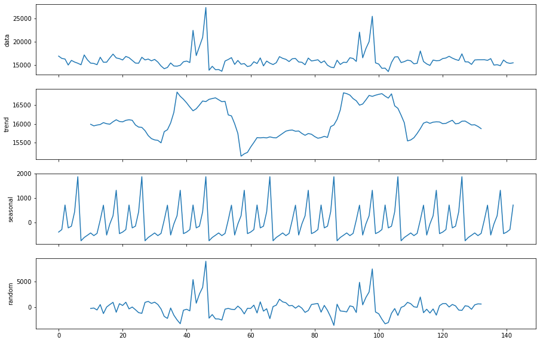

```python
decomposed = decompose(df_weekly['Weekly_Sales'].values, 'additive', m = 20)
decomposed_plot(decomposed, figure_kwargs={'figsize': (15, 10)})
plt.show()
```

The seasonal period looks to be 20 here for the additive model.

Though I chose 20 to be the value, I'd like to check if there is any other value which gives better MSE than m = 20

```
10
1850109.1831723857
15
1005218.8586518969
20
854509.6764891606
25
1078895.751733127
30
1728072.5167925854
35
870413.9014615628
40
1510499.9375399495
45
3455267.909297715
```

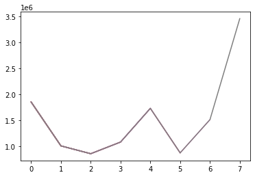

```python
list_mse_exp_smoo = []
for _ in range(10, 50, 5):
    print(_)
    model_holt_winters = ExponentialSmoothing(train_data_diff,
                                              seasonal_periods = _,
                                              seasonal='additive',
                                              trend='additive',
                                              damped = True).fit() #Taking additive trend and seasonality.

    y_pred = model_holt_winters.forecast(len(test_data_diff))# Predict the test data

    #Calculating the MSE
    mse = mean_squared_error(test_data_diff, y_pred)
    print(mse)
    list_mse_exp_smoo.append(mse)
    plt.plot(np.array(list_mse_exp_smoo))
```

It appears that m=20 gives the least MSE thus was the right choice.

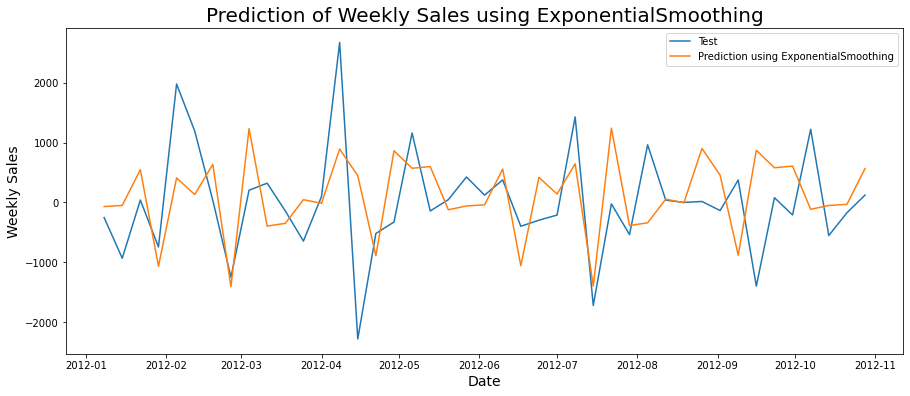

```python
model_holt_winters = ExponentialSmoothing(train_data_diff,
                                              seasonal_periods = 20,
                                              seasonal='additive',
                                              trend='additive',
                                              damped = True).fit() #Taking additive trend and seasonality.

y_pred = model_holt_winters.forecast(len(test_data_diff))# Predict the test data
# Visualize train, test and predicted data.
plt.figure(figsize=(15,6))
plt.title('Prediction of Weekly Sales using ExponentialSmoothing', fontsize=20)
# plt.plot(train_data_diff, label='Train')
plt.plot(test_data_diff, label='Test')
plt.plot(y_pred, label='Prediction using ExponentialSmoothing')
plt.legend(loc='best')
plt.xlabel('Date', fontsize=14)
plt.ylabel('Weekly Sales', fontsize=14)
plt.show()
```

The MSE of the Holts-Winter Exponential Smoothing technique withe the m = 20 is **854509.68** which is the least MSE of all the techniques used through out the project.

I hope you enjoyed reading and learning from the notebook as much as I enjoyed creating this notebook.

Please feel free to comment / give feedback / suggest improvement on this notebook.

Thank you!